# Proyecto 2

Marco Ramirez, Estuardo Hernandez, Alfredo Quezada

2022-09-19

## Prediccion de argumentos efectivos

El objetivo de este proyecto es clasificar los elementos argumentativos en la escritura de los estudiantes como “efectivos”, “adecuados” o “ineficaces”. Esto mediante los datos proporcionados por Kaggle.

### Situacion problematica

Partimos de la base, que una escrituta argumentativa ayuda a el crecimiento del pensamiento critito, dicho eso, solo el 13% de los catedraticos piden a sus alumnos que escriban de manera persuasiva, si quitamos ese 13% de alumnos que llegan a tener esa practica constante, resulta una cantidad de jovenes que no logran fomentar sus habilidades, si bien es cierto que a dia de hoy existe una cantidad abundante de herramientas en linea que permiten una retroalimentacion automatizada, no llega a similar ni siquiera igualar, la practica que se adquiere mediante el metodo tradicional.

### Problema cientifico

Por tanto, nos topamos con el problema de que no todos desarrollan una calidad aceptable de elementos argumentativos, desarrollo de ideas o la organizacion de ideas, por lo tanto, se estable una investigacion para determinar la calidad de los argumentos, en base a su efectividad.

### Objetivos

**- Objetivos generales:**

1. Catalogar los argumentos en base a su efectividad.
2. Determinar el tipo de discurso con mayor efectividad.

**- Obetivos especificos:**

1. Catalogar discurosos como **Ineficaz** , **Adeacuado** o **Eficaz**
2. Identificar los sentimientos obtenidos en base a los discursos realizados.

### Descripcion de los datos

```r
db<- read.csv('train.csv')
```

El conjunto de datos contiene ensayos argumentativos escritos por estudiantes estadounidenses en los grados 6-12. Estos ensayos fueron anotados por calificadores expertos para los elementos del discurso que se encuentran comúnmente en la escritura argumentativa:

-Lead: una introducción que comienza con una estadística, una cita, una descripción o algún otro dispositivo para captar la atención del lector y apuntar hacia la tesis.

-Position: una opinión o conclusión sobre la pregunta principal.

-Claim: un reclamo que respalda la posición.

-Counterclaim: una afirmación que refuta otra afirmación o da una razón opuesta a la posición.

-Rebuttal: una afirmación que refuta una contrademanda.

-Evidence: ideas o ejemplos que respaldan afirmaciones, reconvenciones o refutaciones.

-Concluding Statement: una declaración de conclusión que reafirma las afirmaciones.

#### Descripción del dataframe

-discourse_id: código de identificación para el elemento de discurso. Variable categórica. -essay_id: código de identificación para la respuesta del ensayo. Variable categórica. -discourse_text: texto del elemento del discurso. Variable categórica. -discourse_type: etiqueta de clase del elemento de discurso. Variable categórica. -discourse_effectiveness: calificación de la calidad del elemento del discurso, el objetivo. Variable categórica.

#### Representación gráfica de los datos

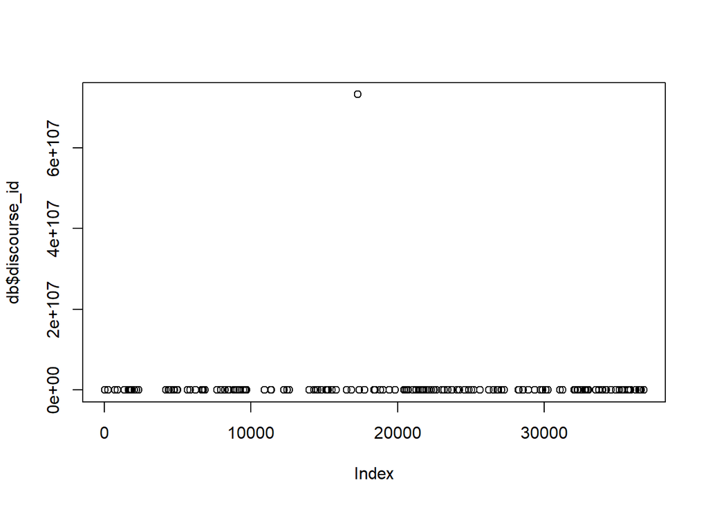

```r
plot(x = db$discourse_id)
```

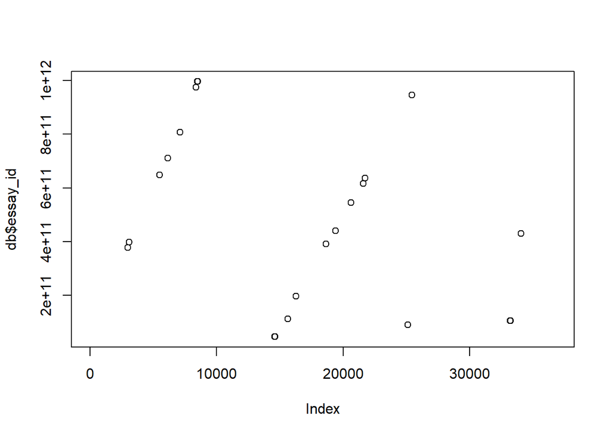

```r
plot(x = db$essay_id)
```

### Analisis Exploratorio

La base de datos cuenta con 36765 filas y 5 columnas

```r
# Librerias necesarias

library("tm")
library("SnowballC")
library("wordcloud")
library("RColorBrewer")
library("syuzhet")
library("ggplot2")
library(dplyr)
# Limpiamos el texto
```

#### 1. ¿Cuál es el tipo de discurso predominante?

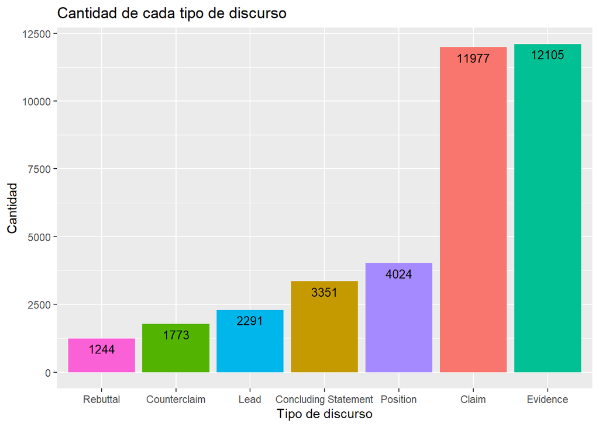

```r
disType <- db %>%
  group_by(db$discourse_type) %>%
  tally()

colnames(disType)[1]<-'Tipo'
colnames(disType)[2]<-'Cantidad'

ggplot(data=disType, aes(x=reorder(Tipo,Cantidad), y=Cantidad,fill=Tipo)) +
  geom_bar(stat="identity", position=position_dodge())+
  geom_text(aes(label=Cantidad), vjust=1.6, color="black",
            position = position_dodge(0.9), size=3.5)+
  labs(title="Cantidad de cada tipo de discurso",x='Tipo de discurso', y="Cantidad")+
  theme(legend.position="none")
```

Como se observa en la grafica anterior el tipo de discurso predominante es ‘Evidence’, el cual se refiere a ideas o ejemplos que respaldan afirmaciones, reconvenciones o refutaciones. Y en en segundo puesto se encuentra ‘Claim’, el cual es un reclamo que respalda alguna posicion.

#### Cantidad de discursos categorizados como ineficaz, adecuado y eficaz

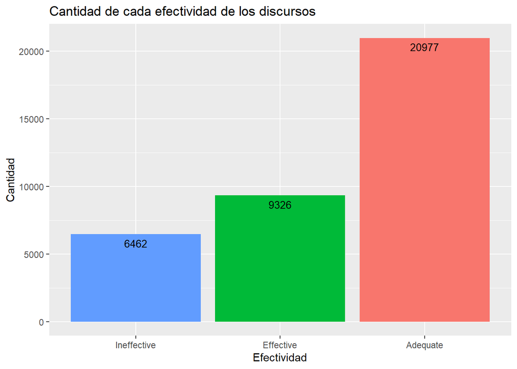

```r
cantType <- db %>%
  group_by(db$discourse_effectiveness) %>%
  tally()

colnames(cantType)[1]<-'Tipo'
colnames(cantType)[2]<-'Cantidad'

ggplot(data=cantType, aes(x=reorder(Tipo,Cantidad), y=Cantidad,fill=Tipo)) +
  geom_bar(stat="identity", position=position_dodge())+
  geom_text(aes(label=Cantidad), vjust=1.6, color="black",
            position = position_dodge(0.9), size=3.5)+
  labs(title="Cantidad de cada efectividad de los discursos",x='Efectividad', y="Cantidad")+
  theme(legend.position="none")
```

Como se observa, los 3 tipos de efectividad no se encuentran balanceados, ademas, la efectividad predominante es ‘Adequate’ con una cantidad de ‘20977’ discursos. ‘Effective’ con una cantidad de ‘9326’ e ‘Ineffective’ con una cantidad de ‘6462’

#### Analisis del los discursos

##### Analisis del discurso sin limpieza

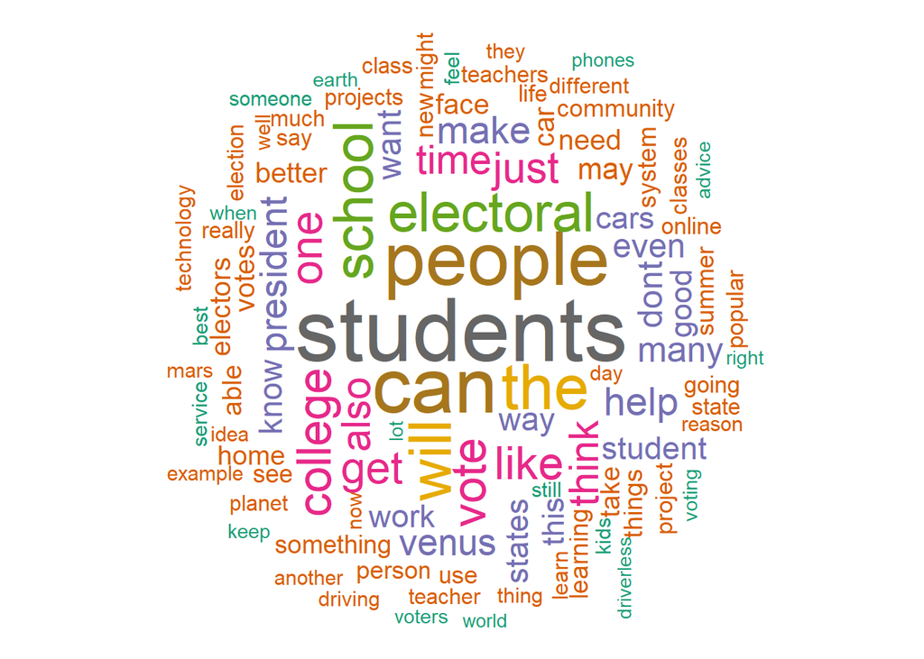

```r
wordcloud(words = db$discourse_text,
          max.words=100, random.order=FALSE, rot.per=0.40,
          colors=brewer.pal(8, "Dark2"))
```

Ahora veremos como se ve una nube de palabras con una limpieza de datos.

```r
TextDoc <- Corpus(VectorSource(db$discourse_text))
#Replacing "/", "@" and "|" with space
toSpace <- content_transformer(function (x , pattern ) gsub(pattern, " ", x))
TextDoc <- tm_map(TextDoc, toSpace, "/")
TextDoc <- tm_map(TextDoc, toSpace, "@")
TextDoc <- tm_map(TextDoc, toSpace, "\\|")
# Convert the text to lower case
TextDoc <- tm_map(TextDoc, content_transformer(tolower))
# Remove numbers
TextDoc <- tm_map(TextDoc, removeNumbers)
# Remove english common stopwords
TextDoc <- tm_map(TextDoc, removeWords, stopwords("english"))
# Remove your own stop word
# specify your custom stopwords as a character vector
TextDoc <- tm_map(TextDoc, removeWords, c("like", "just", "get",'will','new','now','via','dont','one','can'))
# Remove punctuations
TextDoc <- tm_map(TextDoc, removePunctuation)
# Eliminate extra white spaces
TextDoc <- tm_map(TextDoc, stripWhitespace)
# Text stemming - which reduces words to their root form
TextDoc <- tm_map(TextDoc, stemDocument)

TextDoc_dtm <- TermDocumentMatrix(TextDoc)
dtm_m <- as.matrix(TextDoc_dtm)
 # Sort by descearing value of frequency
dtm_v <- sort(rowSums(dtm_m),decreasing=TRUE)
dtm_d <- data.frame(word = names(dtm_v),freq=dtm_v)
# Display the top 5 most frequent words
head(dtm_d)
```

```
##            word  freq
## student student 15823
## peopl     peopl 10835
## vote       vote 10537
## elector elector 10071
## school   school  8639
## make       make  6495
```

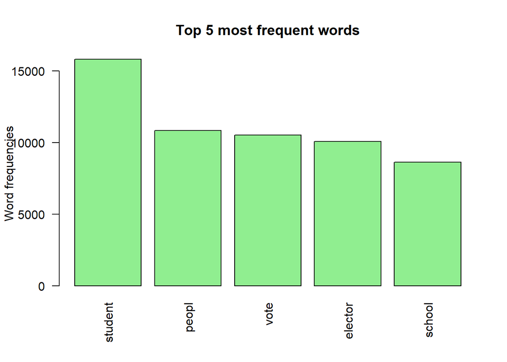

```r
# Plot the most frequent words
barplot(dtm_d[1:5,]$freq, las = 2, names.arg = dtm_d[1:5,]$word,
        col ="lightgreen", main ="Top 5 most frequent words",
        ylab = "Word frequencies")
```

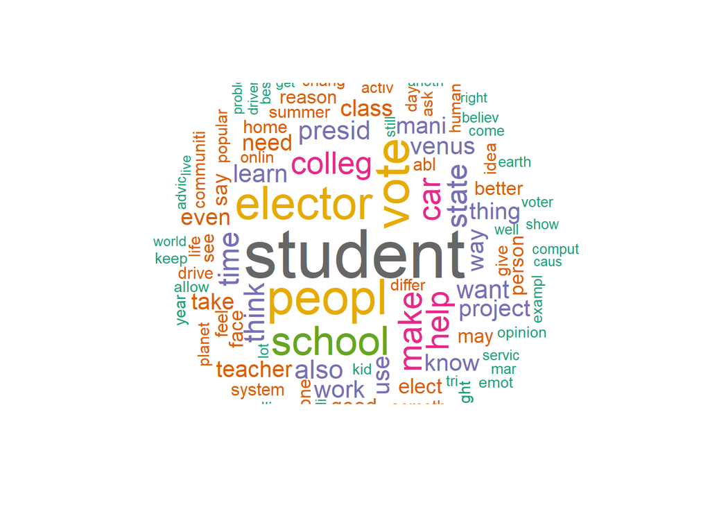

```r
set.seed(1234)
wordcloud(words = dtm_d$word, freq = dtm_d$freq, min.freq = 5,
          max.words=100, random.order=FALSE, rot.per=0.40,
          colors=brewer.pal(8, "Dark2"))
```

Como se observa la palabra *Student* sigue predominando en los discursos de los estudiantes, asi como *people* y *vote*

##### Analisis de sentimiento en los discursos

```r
syuzhet_vector <- get_sentiment(db$discourse_text, method="syuzhet")
# see the first row of the vector
head(syuzhet_vector)
```

```
## [1] 0.6 0.6 0.6 2.6 0.0 0.0
```

```r
# see summary statistics of the vector
summary(syuzhet_vector)
```

```
##    Min. 1st Qu.  Median    Mean 3rd Qu.    Max.
## -8.5000  0.0000  0.7000  0.9379  1.5500 17.6500
```

```r
# bing
bing_vector <- get_sentiment(db$discourse_text, method="bing")
head(bing_vector)
```

```
## [1] 0 0 0 1 0 0
```

```r
summary(bing_vector)
```

```
##     Min.  1st Qu.   Median     Mean  3rd Qu.     Max.
## -13.0000   0.0000   0.0000   0.5961   1.0000  15.0000
```

```r
#affin
afinn_vector <- get_sentiment(db$discourse_text, method="afinn")
head(afinn_vector)
```

```
## [1]  1  1  0  2  0 -1
```

```r
summary(afinn_vector)
```

```
##    Min. 1st Qu.  Median    Mean 3rd Qu.    Max.
## -28.000   0.000   1.000   1.637   3.000  39.000
```

```r
#compare the first row of each vector using sign function
rbind(
  sign(head(syuzhet_vector)),
  sign(head(bing_vector)),
  sign(head(afinn_vector))
)
```

```
##      [,1] [,2] [,3] [,4] [,5] [,6]
## [1,]    1    1    1    1    0    0
## [2,]    0    0    0    1    0    0
## [3,]    1    1    0    1    0   -1
```

```r
d<-get_nrc_sentiment(db$discourse_text)
# head(d,10) - to see top 10 lines of the get_nrc_sentiment dataframe
head (d,10)
```

```
##    anger anticipation disgust fear joy sadness surprise trust negative positive
## 1      0            0       0    0   0       0        0     0        0        0
## 2      0            0       0    0   0       0        0     0        0        0
## 3      0            0       0    0   0       0        0     0        0        0
## 4      0            0       0    0   1       0        0     0        0        2
## 5      0            1       0    0   0       0        0     0        0        0
## 6      0            0       0    0   0       0        0     0        0        0
## 7      0            1       0    0   0       0        0     0        0        0
## 8      0            1       0    0   1       0        0     0        0        1
## 9      0            0       0    0   0       0        0     0        0        0
## 10     0            1       0    0   1       0        0     8        1        4
```

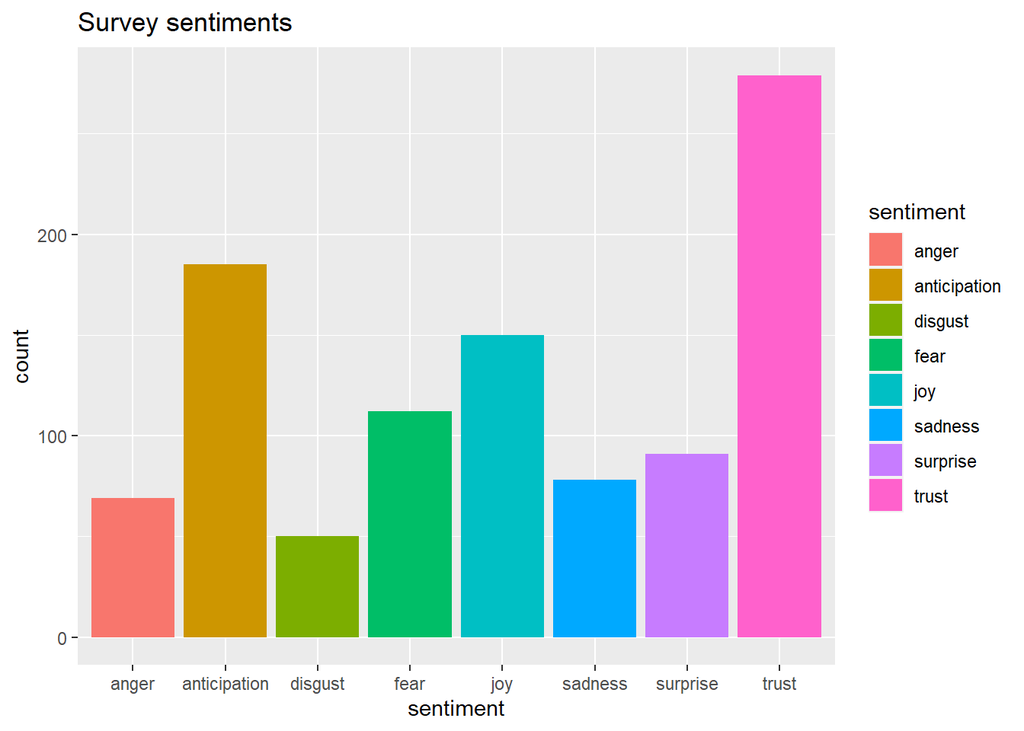

```r
db$Enojo<- d$anger
db$Anticipacion<- d$anticipation
db$Disgusto<- d$disgust
db$Miedo<- d$fear
db$Felicidad<- d$joy
db$Tristeza<- d$sadness
db$Sorpresa<- d$surprise
db$Verdad<- d$trust
db$Negativo<- d$negative
db$Positivo<- d$positive



#transpose
td<-data.frame(t(d))
#The function rowSums computes column sums across rows for each level of a grouping variable.
td_new <- data.frame(rowSums(td[2:253]))
#Transformation and cleaning
names(td_new)[1] <- "count"
td_new <- cbind("sentiment" = rownames(td_new), td_new)
rownames(td_new) <- NULL
td_new2<-td_new[1:8,]
#Plot One - count of words associated with each sentiment
quickplot(sentiment, data=td_new2, weight=count, geom="bar", fill=sentiment, ylab="count")+ggtitle("Survey sentiments")
```

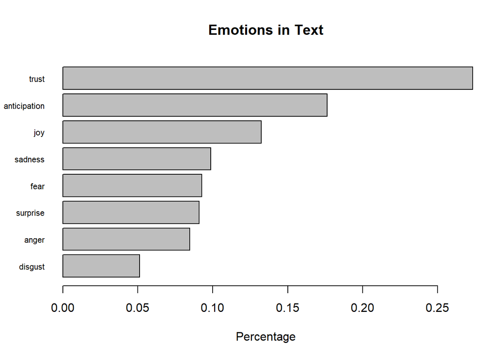

```r
#Plot two - count of words associated with each sentiment, expressed as a percentage
barplot(
  sort(colSums(prop.table(d[, 1:8]))),
  horiz = TRUE,
  cex.names = 0.7,
  las = 1,
  main = "Emotions in Text", xlab="Percentage"
)
```

```r
ineficiente<-subset(db, db$discourse_effectiveness=="Ineffective")
summary(ineficiente)
```

```
##  discourse_id         essay_id         discourse_text     discourse_type
##  Length:6462        Length:6462        Length:6462        Length:6462
##  Class :character   Class :character   Class :character   Class :character
##  Mode  :character   Mode  :character   Mode  :character   Mode  :character
##
##
##
##  discourse_effectiveness     Enojo         Anticipacion        Disgusto
##  Length:6462             Min.   :0.0000   Min.   : 0.0000   Min.   :0.0000
##  Class :character        1st Qu.:0.0000   1st Qu.: 0.0000   1st Qu.:0.0000
##  Mode  :character        Median :0.0000   Median : 1.0000   Median :0.0000
##                          Mean   :0.4559   Mean   : 0.8781   Mean   :0.2849
##                          3rd Qu.:1.0000   3rd Qu.: 1.0000   3rd Qu.:0.0000
##                          Max.   :9.0000   Max.   :10.0000   Max.   :7.0000
##      Miedo           Felicidad          Tristeza          Sorpresa
##  Min.   : 0.0000   Min.   : 0.0000   Min.   : 0.0000   Min.   :0.0000
##  1st Qu.: 0.0000   1st Qu.: 0.0000   1st Qu.: 0.0000   1st Qu.:0.0000
##  Median : 0.0000   Median : 0.0000   Median : 0.0000   Median :0.0000
##  Mean   : 0.4449   Mean   : 0.6998   Mean   : 0.4989   Mean   :0.5118
##  3rd Qu.: 1.0000   3rd Qu.: 1.0000   3rd Qu.: 1.0000   3rd Qu.:1.0000
##  Max.   :11.0000   Max.   :10.0000   Max.   :10.0000   Max.   :9.0000
##      Verdad          Negativo          Positivo
##  Min.   : 0.000   Min.   : 0.0000   Min.   : 0.000
##  1st Qu.: 0.000   1st Qu.: 0.0000   1st Qu.: 0.000
##  Median : 1.000   Median : 0.0000   Median : 1.000
##  Mean   : 1.338   Mean   : 0.8955   Mean   : 1.989
##  3rd Qu.: 2.000   3rd Qu.: 1.0000   3rd Qu.: 3.000
##  Max.   :14.000   Max.   :18.0000   Max.   :27.000
```

```r
Efectivo<-subset(db, db$discourse_effectiveness=="Effective")
summary(Efectivo)
```

```
##  discourse_id         essay_id         discourse_text     discourse_type
##  Length:9326        Length:9326        Length:9326        Length:9326
##  Class :character   Class :character   Class :character   Class :character
##  Mode  :character   Mode  :character   Mode  :character   Mode  :character
##
##
##
##  discourse_effectiveness     Enojo         Anticipacion      Disgusto
##  Length:9326             Min.   :0.0000   Min.   : 0.00   Min.   :0.0000
##  Class :character        1st Qu.:0.0000   1st Qu.: 0.00   1st Qu.:0.0000
##  Mode  :character        Median :0.0000   Median : 1.00   Median :0.0000
##                          Mean   :0.5109   Mean   : 1.22   Mean   :0.2922
##                          3rd Qu.:1.0000   3rd Qu.: 2.00   3rd Qu.:0.0000
##                          Max.   :8.0000   Max.   :13.00   Max.   :7.0000
##      Miedo           Felicidad          Tristeza          Sorpresa
##  Min.   : 0.0000   Min.   : 0.0000   Min.   : 0.0000   Min.   :0.0000
##  1st Qu.: 0.0000   1st Qu.: 0.0000   1st Qu.: 0.0000   1st Qu.:0.0000
##  Median : 0.0000   Median : 0.0000   Median : 0.0000   Median :0.0000
##  Mean   : 0.6288   Mean   : 0.8719   Mean   : 0.6514   Mean   :0.5298
##  3rd Qu.: 1.0000   3rd Qu.: 1.0000   3rd Qu.: 1.0000   3rd Qu.:1.0000
##  Max.   :14.0000   Max.   :10.0000   Max.   :13.0000   Max.   :6.0000
##      Verdad          Negativo         Positivo
##  Min.   : 0.000   Min.   : 0.000   Min.   : 0.000
##  1st Qu.: 0.000   1st Qu.: 0.000   1st Qu.: 1.000
##  Median : 1.000   Median : 1.000   Median : 2.000
##  Mean   : 1.864   Mean   : 1.241   Mean   : 3.184
##  3rd Qu.: 3.000   3rd Qu.: 2.000   3rd Qu.: 5.000
##  Max.   :15.000   Max.   :18.000   Max.   :24.000
```

```r
Adecuado<-subset(db, db$discourse_effectiveness=="Adequate")
summary(Adecuado)
```

```
##  discourse_id         essay_id         discourse_text     discourse_type
##  Length:20977       Length:20977       Length:20977       Length:20977
##  Class :character   Class :character   Class :character   Class :character
##  Mode  :character   Mode  :character   Mode  :character   Mode  :character
##
##
##
##  discourse_effectiveness     Enojo         Anticipacion       Disgusto
##  Length:20977            Min.   :0.0000   Min.   : 0.000   Min.   :0.000
##  Class :character        1st Qu.:0.0000   1st Qu.: 0.000   1st Qu.:0.000
##  Mode  :character        Median :0.0000   Median : 0.000   Median :0.000
##                          Mean   :0.3468   Mean   : 0.677   Mean   :0.216
##                          3rd Qu.:1.0000   3rd Qu.: 1.000   3rd Qu.:0.000
##                          Max.   :7.0000   Max.   :12.000   Max.   :6.000
##      Miedo          Felicidad         Tristeza          Sorpresa
##  Min.   :0.0000   Min.   :0.0000   Min.   : 0.0000   Min.   :0.0000
##  1st Qu.:0.0000   1st Qu.:0.0000   1st Qu.: 0.0000   1st Qu.:0.0000
##  Median :0.0000   Median :0.0000   Median : 0.0000   Median :0.0000
##  Mean   :0.3662   Mean   :0.5154   Mean   : 0.3905   Mean   :0.3744
##  3rd Qu.:1.0000   3rd Qu.:1.0000   3rd Qu.: 1.0000   3rd Qu.:1.0000
##  Max.   :7.0000   Max.   :9.0000   Max.   :11.0000   Max.   :8.0000
##      Verdad          Negativo          Positivo
##  Min.   : 0.000   Min.   : 0.0000   Min.   : 0.000
##  1st Qu.: 0.000   1st Qu.: 0.0000   1st Qu.: 0.000
##  Median : 1.000   Median : 0.0000   Median : 1.000
##  Mean   : 1.069   Mean   : 0.7057   Mean   : 1.624
##  3rd Qu.: 2.000   3rd Qu.: 1.0000   3rd Qu.: 2.000
##  Max.   :13.000   Max.   :16.0000   Max.   :25.000
```

```r
resumen<-data.frame(Categoria= c("Ineficiente","Adecuado","Eficiente"),
                    Enojo= c(mean(ineficiente$Enojo),mean(Adecuado$Enojo),mean(Efectivo$Enojo)),
                    Anticipacion= c(mean(ineficiente$Anticipacion),mean(Adecuado$Anticipacion),mean(Efectivo$Anticipacion)),
                    Disgusto= c(mean(ineficiente$Disgusto),mean(Adecuado$Disgusto),mean(Efectivo$Disgusto)),
                    Miedo= c(mean(ineficiente$Miedo),mean(Adecuado$Miedo),mean(Efectivo$Miedo)),
                    Felicidad= c(mean(ineficiente$Felicidad),mean(Adecuado$Felicidad),mean(Efectivo$Felicidad)),
                    Tristeza= c(mean(ineficiente$Tristeza),mean(Adecuado$Tristeza),mean(Efectivo$Tristeza)),
                    Sorpresa= c(mean(ineficiente$Sorpresa),mean(Adecuado$Sorpresa),mean(Efectivo$Sorpresa)),
                    Verdad= c(mean(ineficiente$Verdad),mean(Adecuado$Verdad),mean(Efectivo$Verdad)),
                    Negativo= c(mean(ineficiente$Negativo),mean(Adecuado$Negativo),mean(Efectivo$Negativo)),
                    Positivo= c(mean(ineficiente$Positivo),mean(Adecuado$Positivo),mean(Efectivo$Positivo))

                    )

resumen
```

```
##     Categoria     Enojo Anticipacion  Disgusto     Miedo Felicidad  Tristeza
## 1 Ineficiente 0.4558960    0.8780563 0.2848963 0.4449087 0.6997833 0.4989167
## 2    Adecuado 0.3468084    0.6769795 0.2160461 0.3661629 0.5153740 0.3904753
## 3   Eficiente 0.5109372    1.2201373 0.2921939 0.6287798 0.8718636 0.6514047
##    Sorpresa   Verdad  Negativo Positivo
## 1 0.5117611 1.337512 0.8955432 1.989013
## 2 0.3743624 1.069219 0.7056776 1.624255
## 3 0.5298091 1.863607 1.2408321 3.184431
```

Como se observa los argumentos mas eficientes es cuando poseen mas sentimiento, ya que como se observa anteriormente, la categoria de eficiente lidera en todos los sentimientos, dando a entender que el texto logra expresar de manera eficiente lo que el autor quiere explicar.

##### Cantidad de palabras

```r
require(stringr)
```

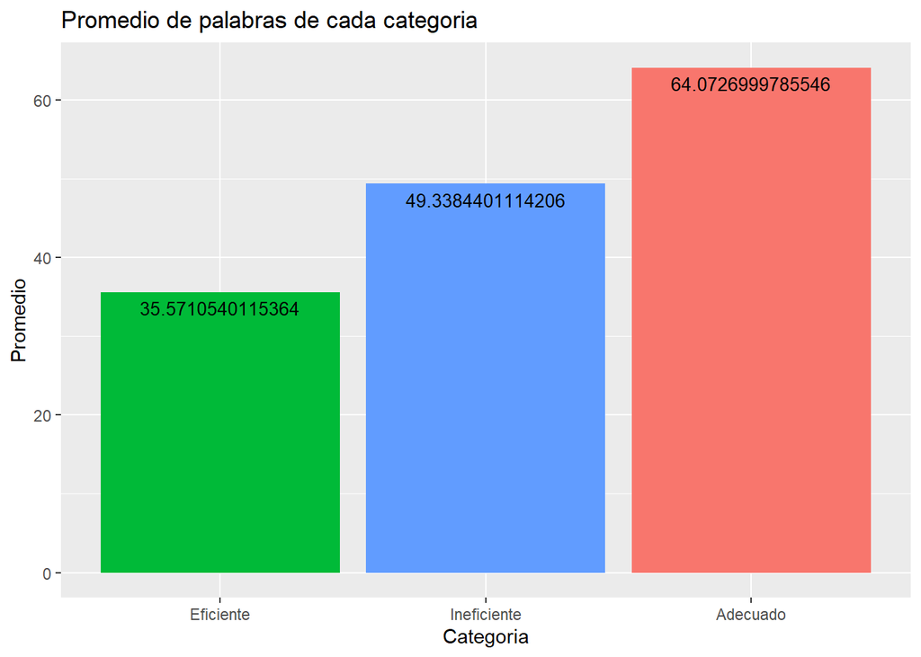

```r
db<-read.csv("train.csv")

db$CantidadPalabras<-str_count(db$discourse_text, '\\w+')

ineficiente<-subset(db, db$discourse_effectiveness=="Ineffective")

Efectivo<-subset(db, db$discourse_effectiveness=="Effective")

Adecuado<-subset(db, db$discourse_effectiveness=="Adequate")

resumen<-data.frame(Categoria= c("Ineficiente","Adecuado","Eficiente"),
                    Promedio=c(mean(ineficiente$CantidadPalabras),mean(Efectivo$CantidadPalabras),mean(Adecuado$CantidadPalabras)))

ggplot(data=resumen, aes(x=reorder(Categoria,Promedio), y=Promedio,fill=Categoria)) +
  geom_bar(stat="identity", position=position_dodge())+
  geom_text(aes(label=Promedio), vjust=1.6, color="black",
            position = position_dodge(0.9), size=3.5)+
  labs(title="Promedio de palabras de cada categoria",x='Categoria', y="Promedio")+
  theme(legend.position="none")
```